# Notebook

#

Introduction to Python Workshop

Kareem Carr

IQSS Research Consulting Team  
Support for data analysis, programming, research design and organization, storage and sharing of data.  
email: support@help.hmdc.harvard.edu  
website: http://projects.iq.harvard.edu/rtc

Download Python workshop materials from  
http://tutorials.iq.harvard.edu/Python/introPython/filesforpythonclass.zip

Why learn python?  
It's a good big data language.

1. Emphasizes clean, clear code. This makes it easier for teams of people to work on code.
2. Emphasizes minimizing the amount of coding you have to do.
3. Emphasizes having one way of doing things. This helps with points one and two.
4. Emphasizes modularity and good documentation.
5. Good for talking to other code and running other programs. This means you can use python to crunch huge amounts of data.
6. Good for manipulating text.
7. Solid numerical computing and machine learning platform.

The [zen](http://legacy.python.org/dev/peps/pep-0020/) of python

> Beautiful is better than ugly.

> Explicit is better than implicit.

> Simple is better than complex.

Objectives of the Workshop

Before leaving the workshop:

Have working python environment on your laptop

Know how to talk to the python interpreter

Know where to find out more about python

Know how to get data into python, use functions and do a few basic operations

The Basics of Python

During the exercise if you would like to insert a cell so you can add your own commands do ctrl-m and then press b.

## What is the simplest python program?

```python
print "Hello World!"
```

```python
%run simple.py
```

## Built-in functions

```python
min(42,53) #minimum
```

```python
max(42,53) #maximum
```

```python
len("hello") #length of the string "hello"
```

```python
round(4.5) #round values
```

```python
4 == 5 #boolean
```

```python
"hello" == 'hello'
```

There are four basic types of data in python: boolean, strings, floats and integers. Strings are text. Integers are integers, one of the two types of numbers. Floats are the equivalent of decimals.

```python
print type(1)
print type(2.4)
print type("hello")
print type(True)
print type(min)
```

Using variables

```python
x = 4
y = 5
z = x+y
print x, y, z
```

```python
x = 5
print type(x)
x = "hello"
print type(x)
```

### Operations with strings

```python
"Hello. How are you today?".split()
```

```python
print "".join(['Hello.', 'How', 'are', 'you', 'today?'])
```

```python
print " ".join(['Hello.', 'How', 'are', 'you', 'today?'])
```

```python
"Hello.".startswith("H")
```

```python
"Hello.".startswith("h")
```

```python
"Hello.".endswith(".")
```

```python
print "H" in "Hello" #returns a boolean
print "Hello" in "Hello. How are you today?" #returns a boolean
```

## Getting more functions using modules

You can use the import statement to get more functions in python

### string

```python
#https://docs.python.org/2/library/string.html
import string
```

```python
print string.punctuation
print string.digits
print string.ascii_letters
```

### math

```python
#https://docs.python.org/2/library/math.html
import math
```

```python
print math.log(0.2)
print math.exp(4)
```

### random

```python
#https://docs.python.org/2/library/random.html
import random
```

```python
print random.random() # random real number between 0 and 1
print random.randint(0,5) #random integer between 0 and 5
```

### user-defined functions

```python
def f(x):
    return x+1

print f(2)
```

```python
def f(x,y):
    return x+y

print f(2,3)
```

```python
def f(first_name,last_name):
    first_initial = first_name[0]
    last_initial = last_name[0]
    return first_initial+"."+last_initial+"."

print f("John","Smith")
```

### user-defined modules

```python
import myfile
```

```python
myfile.f(1,3)
```

Objectives of the Workshop

Before leaving the workshop:

Have working python environment on your laptop

Know how to talk to the python interpreter

Know where to find out more about python

Know how to get data into python, use functions and do a few basic operations

Getting Help

Books

1. [Python the Hard Way](http://learnpythonthehardway.org/)
2. [Oreilly Books](http://shop.oreilly.com/category/browse-subjects/programming/python.do)
3. [Learning Python](http://shop.oreilly.com/product/0636920028154.do)

Websites

1. [Python.org](https://www.python.org/)
2. [Stack Overflow](http://stackoverflow.com/)

```python
help(math.exp)
```

```python
math.exp?
```

```python
help("math")
```

```python
dir(math)
```

```python
import myfile
```

```python
help(myfile.g)
```

Objectives of the Workshop

Before leaving the workshop:

Have working python environment on your laptop

Know how to talk to the python interpreter

Know where to find out more about python

Know how to get data into python, use functions and do a few basic operations

Complex Data Types

### lists

```python
"A camel can go periods of time without drinking water.".split()
```

```python
x = "A camel can go periods of time without drinking water.".split()
type(x)
```

```python
words = "A camel can go periods of time without drinking water.".split()
```

```python
print words[0]
print words[1]
print words[9]
print words[-1]
print words[1:3]
print words[1:]
print words[:3]
print len(words)
```

```python
range(5)
```

```python
x = ['a','c']

print x
x.append('b')
print x

x.sort()
print x

x.remove('a')
print x
```

```python
for thing in range(5):
    print thing
```

```python
for item in range(5):
    print item
```

```python
for word in words:
    print word
```

```python
for word in words:
    if word.startswith("c"):
        print word
```

```python
[word for word in words]
```

```python
[len(word) for word in words]
```

```python
[len(word) for word in words if word.startswith('c')]
```

```python
map(len,words)
```

```python
def startswith_c(word):
    return word.startswith('c')

print filter(startswith_c, words)
print map(len, filter(startswith_c, words) )
```

### dictionaries

```python
category=dict()
category["apple"]="fruit"
category["banana"]="fruit"
category["cherry"]="fruit"
category["celery"]="vegetable"
category["tomato"]="vegetable"
```

```python
category["apple"]
```

```python
category.keys()
```

```python
category.values()
```

```python
category.items()
```

```python
print category
```

```python
data = category.items()
print data
```

```python
data[0]
```

```python
print data[0][0]
print data[0][1]
```

### numpy arrays

```python
#http://wiki.scipy.org/Tentative_NumPy_Tutorial#head-6a1bc005bd80e1b19f812e1e64e0d25d50f99fe2
import numpy as np
```

```python
print [1,2,3,4]+[5,6,7,8]
print [1,2,3,4]+['a','b','c','d']

x = [1,2,3,4]
y = np.array(x)

print type(x)
print type(y)
```

```python
np.array([1,2,3,4])+np.array([5,6,7,8])
```

```python
np.random.random(10)
```

```python
np.mean(np.random.random(1000))
```

##

Manipulating External Data

reading and writing files

```python
file = open("Pride_and_Prejudice.txt")
```

```python
print type(file)
print file
```

```python
file.read()
```

```python
file = open("Pride_and_Prejudice.txt")
```

```python
file.readline()
```

```python
file.readlines()
```

```python
file = open("Pride_and_Prejudice.txt")
text = file.readlines()
for line in text:
    if line.startswith('At'): print line
```

```python
file = open("Pride_and_Prejudice.txt")
text = file.read()
text = text.split()
print len(text)
print np.mean( map(len,text) ) # mean word length
```

```python
set(['a','b','a','c','c','a'])
```

```python
file = open("Pride_and_Prejudice.txt")
text = file.read()
text = text.split()
text = set(text)
print len(text)
```

accessing webpages

```python
#https://docs.python.org/2/library/urllib2.html
import urllib2
#Project Gutenberg. Copy of Alice in Wonderland
#http://www.gutenberg.org/cache/epub/11/pg11.txt
webpage = urllib2.urlopen("http://www.gutenberg.org/cache/epub/11/pg11.txt")
```

```python
text = webpage.readlines()
for line in text:
    if line.startswith('At'): print line
```

```python
webpage = urllib2.urlopen("http://www.gutenberg.org/cache/epub/11/pg11.txt")
outfile = open("output.txt",'w')
text = webpage.readlines()
for line in text:
    if line.startswith('At'): outfile.write(line)
```

file system

```python
#https://docs.python.org/2/library/os.html
import os
```

```python
for root, directories, filenames in os.walk("."):
    print filenames
```

```
['.DS_Store', 'iris.csv', 'myfile.py', 'Pride_and_Prejudice.txt', 'simple.py', 'Workshop October 24.ipynb']
['Workshop October 24-checkpoint.ipynb']
```

```python
for root, directories, filenames in os.walk("."):
    for filename in filenames:
        if filename.endswith(".py"): print filename
```

```
myfile.py
simple.py
```

```python
all_files=list()

for root, directories, filenames in os.walk(".."):
    for filename in filenames:
        if filename.endswith(".py"): all_files.append(file)

print len(all_files)
```

```
14331
```

```python
os.listdir(".")
```

```
['.DS_Store',
 '.ipynb_checkpoints',
 'iris.csv',
 'myfile.py',
 'Pride_and_Prejudice.txt',
 'simple.py',
 'Workshop October 24.ipynb']
```

```python
all_files=list()

for root, directories, files in os.walk(".."):
    for file in files:
        if file.endswith(".py"):
            file = open(file)

print len(all_files)
```

## graphics

```python
#http://matplotlib.org/
import matplotlib.pyplot as plt
```

```python
plt.plot([1,2,3,4],[1,4,9,16])
plt.ylabel('y')
plt.xlabel('x')
plt.show()
```

```python
%matplotlib inline
```

```python
plt.plot([1,2,3,4],[1,4,9,16],color="red",linestyle='--')
plt.ylabel('y')
plt.xlabel('x')
plt.show()
```

```python
plt.plot([1,2,3,4],[1,4,9,16],color="red",linestyle='--')
plt.plot([1,2,3,4],[3,7,9,8],color="blue",linestyle='-.')
plt.ylabel('y')
plt.xlabel('x')
plt.show()
```

```python
file = open("Pride_and_Prejudice.txt")
text = file.read()
text = text.split()
data = map(len, text)
plt.hist(data,color="#ff6347")
plt.xlim(0,16)
plt.show()
```

```python
np.linspace(0.5,16.5,17)
```

```python
plt.hist(data,bins=np.linspace(0.5,16.5,17),color="#ff6347")
plt.xlim(0,16)
plt.title('Distribution of word lengths in P & P')
plt.xlabel('word length')
plt.ylabel('frequency')
plt.show()
```

## tabular data

```python
#http://pandas.pydata.org/
import pandas as pd
```

```python
data = pd.read_csv("iris.csv")
print data
```

```
     Species  sepal length  sepal width  petal length  petal width
0          0           5.1          3.5           1.4          0.2
1          0           4.9          3.0           1.4          0.2
2          0           4.7          3.2           1.3          0.2
3          0           4.6          3.1           1.5          0.2
4          0           5.0          3.6           1.4          0.2
5          0           5.4          3.9           1.7          0.4
6          0           4.6          3.4           1.4          0.3
7          0           5.0          3.4           1.5          0.2
8          0           4.4          2.9           1.4          0.2
9          0           4.9          3.1           1.5          0.1
10         0           5.4          3.7           1.5          0.2
11         0           4.8          3.4           1.6          0.2
12         0           4.8          3.0           1.4          0.1
13         0           4.3          3.0           1.1          0.1
```

[output cut: 49 more lines]

```python
data.columns
```

```
Index([u'Species', u'sepal length', u'sepal width', u'petal length', u'petal width'], dtype='object')
```

```python
data.index
```

```
Int64Index([0, 1, 2, 3, 4, 5, 6, 7, 8, 9, 10, 11, 12, 13, 14, 15, 16, 17, 18, 19, 20, 21, 22, 23, 24, 25, 26, 27, 28, 29, 30, 31, 32, 33, 34, 35, 36, 37, 38, 39, 40, 41, 42, 43, 44, 45, 46, 47, 48, 49, 50, 51, 52, 53, 54, 55, 56, 57, 58, 59, 60, 61, 62, 63, 64, 65, 66, 67, 68, 69, 70, 71, 72, 73, 74…
```

```python
data["sepal length"]
```

```
0     5.1
1     4.9
2     4.7
3     4.6
4     5.0
5     5.4
6     4.6
7     5.0
8     4.4
9     4.9
10    5.4
11    4.8
12    4.8
13    4.3
14    5.8
```

[output cut: 17 more lines]

```python
print data.ix[0]
print
print data.ix[0,1:2]
```

```
Species         0.0
sepal length    5.1
sepal width     3.5
petal length    1.4
petal width     0.2
Name: 0, dtype: float64

sepal length    5.1
Name: 0, dtype: float64
```

```python
plt.scatter(data["sepal length"],data["sepal width"],color="#ff6347")
```

```python
%load_ext rpy2.ipython
```

```python
%Rpush data
```

```python
%R print(summary(data))
```

```
    Species   sepal.length    sepal.width     petal.length    petal.width
 Min.   :0   Min.   :4.300   Min.   :2.000   Min.   :1.000   Min.   :0.100
 1st Qu.:0   1st Qu.:5.100   1st Qu.:2.800   1st Qu.:1.600   1st Qu.:0.300
 Median :1   Median :5.800   Median :3.000   Median :4.350   Median :1.300
 Mean   :1   Mean   :5.843   Mean   :3.054   Mean   :3.759   Mean   :1.199
 3rd Qu.:2   3rd Qu.:6.400   3rd Qu.:3.300   3rd Qu.:5.100   3rd Qu.:1.800
 Max.   :2   Max.   :7.900   Max.   :4.400   Max.   :6.900   Max.   :2.500
```

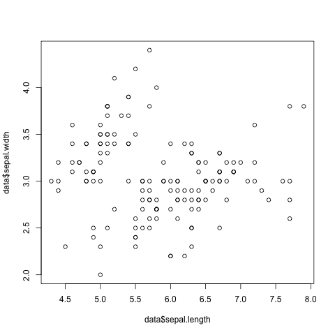

```python
%R plot(data$sepal.length,data$sepal.width)
```

Python culture and the Zen of Python

```python
import this
```

```
The Zen of Python, by Tim Peters

Beautiful is better than ugly.
Explicit is better than implicit.
Simple is better than complex.
Complex is better than complicated.
Flat is better than nested.
Sparse is better than dense.
Readability counts.
Special cases aren't special enough to break the rules.
Although practicality beats purity.
Errors should never pass silently.
Unless explicitly silenced.
In the face of ambiguity, refuse the temptation to guess.
There should be one-- and preferably only one --obvious way to do it.
Although that way may not be obvious at first unless you're Dutch.
Now is better than never.
Although never is often better than *right* now.
If the implementation is hard to explain, it's a bad idea.
If the implementation is easy to explain, it may be a good idea.
Namespaces are one honking great idea -- let's do more of those!
```

Future directions

Style guide  
official python style guide: [PEP-8](http://legacy.python.org/dev/peps/pep-0008/)

Graphics  
matplotlib, seaborn

Webscraping  
urllib2, lxml, BeautifulSoup

Quantitative Data Analysis  
numpy, scipy, scikit-learn, statsmodels

Text analysis  
string, nltk

Social Network Analysis  
igraph, networkx

Using python with R  
rpy2

Python Culture and the Zen of Python

The culture of python is to have code that is simple and readable but gets the job done. The most important of these three is getting the job done!.

# http://stackoverflow.com/questions/228181/the-zen-of-python

import this

#

Objectives of the Workshop

Before leaving the workshop:

Have working python environment on your laptop

Know how to talk to the python interpreter

Know where to find out more about python

Know how to get data into python, use functions and do a few basic operations

Thanks for listening!